# Spaceship Titanic Temporal Anomaly Forecast

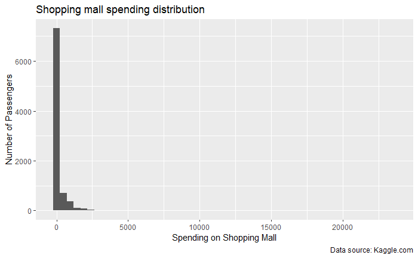

```r
ggplot(train,mapping = aes(x=ShoppingMall)) +
                 geom_histogram(bins = 50) +
                 labs(x = "Spending on Shopping Mall",
                      y = "Number of Passengers",
                      title = "Shopping mall spending distribution",
                      caption = "Data source: Kaggle.com")
```

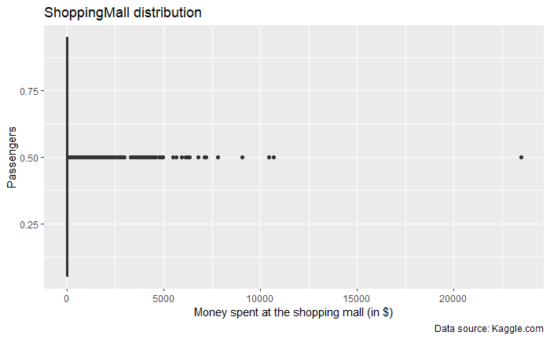

```r
ggplot(train) +
  geom_boxplot(mapping = aes(x=Transported, y=ShoppingMall)) +
  coord_flip() +
        labs(x = "Passengers",
           y = "Money spent at the shopping mall (in $)",
           title = "ShoppingMall distribution",
           caption = "Data source: Kaggle.com")
```

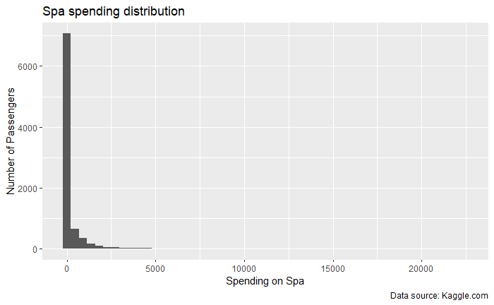

```r
ggplot(train,mapping = aes(x=Spa)) +
                 geom_histogram(bins = 50) +
                 labs(x = "Spending on Spa",
                      y = "Number of Passengers",
                      title = "Spa spending distribution",
                      caption = "Data source: Kaggle.com")
```

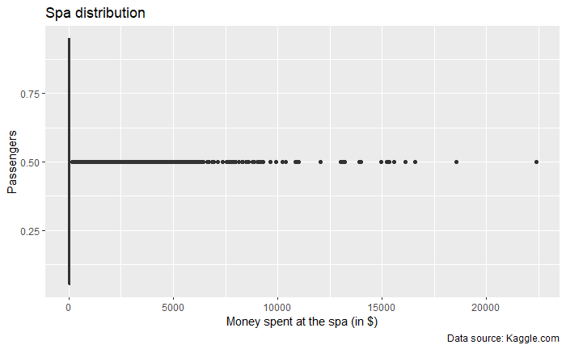

```r
ggplot(train) +
  geom_boxplot(mapping = aes(x=Transported, y=Spa)) +
  coord_flip() +
        labs(x = "Passengers",
           y = "Money spent at the spa (in $)",
           title = "Spa distribution",
           caption = "Data source: Kaggle.com")
```

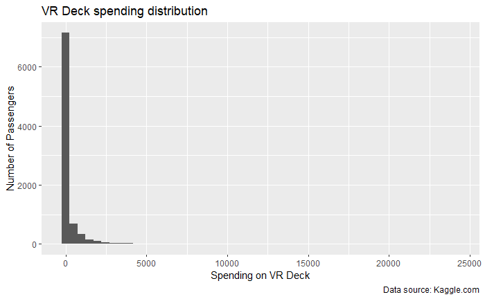

```r
ggplot(train,mapping = aes(x=VRDeck)) +
                 geom_histogram(bins = 50) +
                 labs(x = "Spending on VR Deck",
                      y = "Number of Passengers",
                      title = "VR Deck spending distribution",
                      caption = "Data source: Kaggle.com")
```

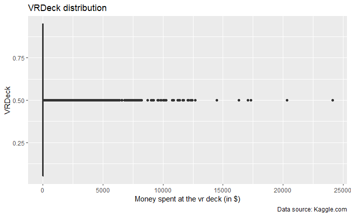

```r
ggplot(train) +
  geom_boxplot(mapping = aes(x=Transported, y=VRDeck)) +
  coord_flip() +
        labs(x = "VRDeck",
           y = "Money spent at the vr deck (in $)",
           title = "VRDeck distribution",
           caption = "Data source: Kaggle.com")
```

```r
NA
```

We have a lot of young passengers, the amenities are dominated by people who did not spend anything.

We therefore decided to see how the log transform look like for amenities to get a better big picture view of their distributions.

There are also some outliers, but on inspection we believe they represent natural variations in the data, i.e. true outliers, so we are not handling them.

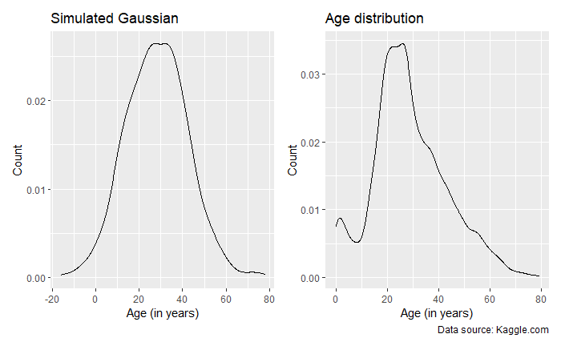

```r
train_no_na <- drop_na(train)


simulatedGaussianA <- tibble(Age=rnorm(n = 1000,
                        mean=mean(train_no_na$Age),
                        sd = sd(train_no_na$Age)))

simulatedGaussianA %>%
  ggplot()+ geom_density(aes(x=Age)) + labs(x = "Age (in years)",
                      y = "Count", title="Simulated Gaussian")+
      ggplot(train_no_na,mapping = aes(x=Age)) +
                   geom_density() +
                   labs(x = "Age (in years)",
                        y = "Count",
                        title = "Age distribution",
                        caption = "Data source: Kaggle.com")
```

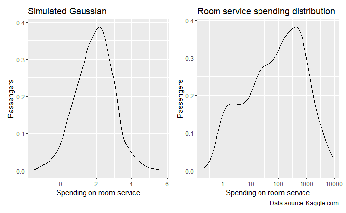

```r
train_no_na <-
  filter(train_no_na,  RoomService> 0, FoodCourt > 0, ShoppingMall > 0,
         Spa > 0, VRDeck > 0)

roomservice <- log10(train_no_na$RoomService)
simulatedGaussianR <- tibble(spending=rnorm(n = 1000,
                        mean=mean(roomservice),
                        sd = sd(roomservice)))

simulatedGaussianR %>%
  ggplot()+ geom_density(aes(x=spending)) + labs(x = "Spending on room service",
                      y = "Passengers", title="Simulated Gaussian") +
  ggplot(train_no_na,mapping = aes(x=RoomService)) +
                 geom_density() +
                 labs(x = "Spending on room service",
                      y = "Passengers",
                      title = "Room service spending distribution",
                      caption = "Data source: Kaggle.com") +
                scale_x_log10()
```

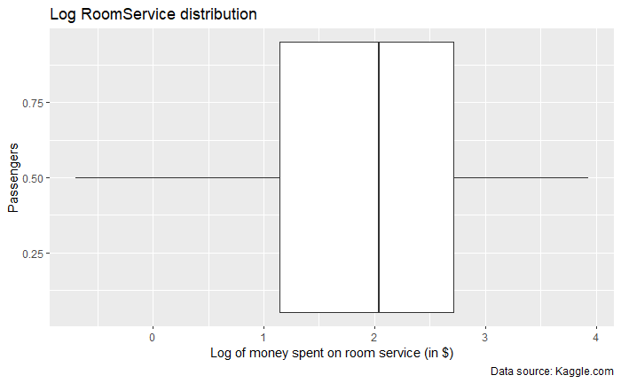

```r
ggplot(train_no_na) +
  geom_boxplot(mapping = aes(x=Transported, y=log10(RoomService))) +
  coord_flip() +
        labs(x = "Passengers",
           y = "Log of money spent on room service (in $)",
           title = "Log RoomService distribution",
           caption = "Data source: Kaggle.com")
```

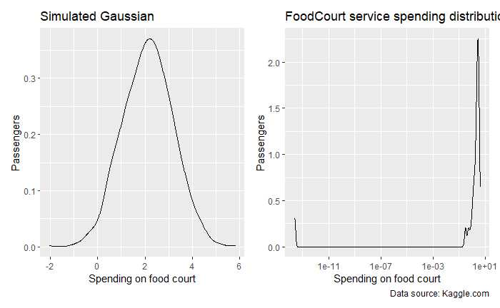

```r
foodcourt <- log10(train_no_na$FoodCourt)
simulatedGaussianF <- tibble(spending=rnorm(n = 1000,
                        mean=mean(foodcourt),
                        sd = sd(foodcourt)))

simulatedGaussianF %>%
  ggplot()+ geom_density(aes(x=spending)) + labs(x = "Spending on food court",
                      y = "Passengers", title="Simulated Gaussian") +
  ggplot(train_no_na,mapping = aes(x=foodcourt)) +
                 geom_density() +
                 labs(x = "Spending on food court",
                      y = "Passengers",
                      title = "FoodCourt service spending distribution",
                      caption = "Data source: Kaggle.com") +
                scale_x_log10()
```

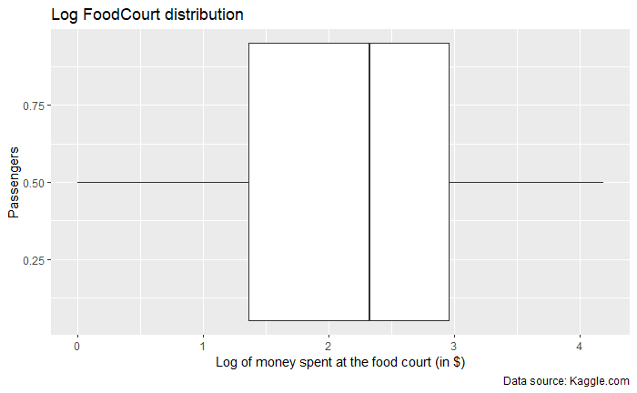

```r
ggplot(train_no_na) +
  geom_boxplot(mapping = aes(x=Transported, y=log10(FoodCourt))) +
  coord_flip() +
        labs(x = "Passengers",
           y = "Log of money spent at the food court (in $)",
           title = "Log FoodCourt distribution",
           caption = "Data source: Kaggle.com")
```

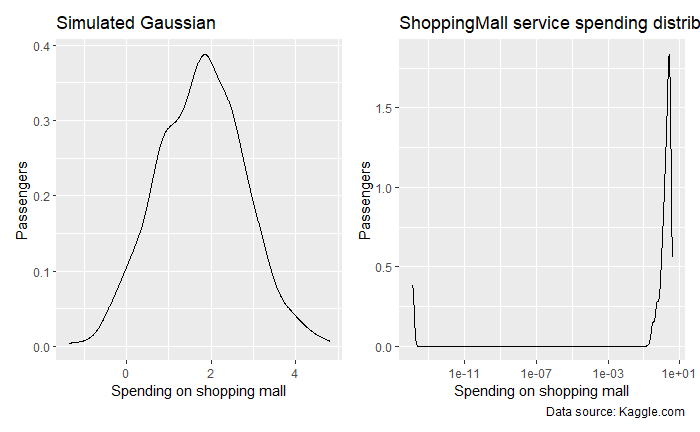

```r
shoppingmall <- log10(train_no_na$ShoppingMall)
simulatedGaussianS <- tibble(spending=rnorm(n = 1000,
                        mean=mean(shoppingmall),
                        sd = sd(shoppingmall)))

simulatedGaussianS %>%
  ggplot()+ geom_density(aes(x=spending)) + labs(x = "Spending on shopping mall",
                      y = "Passengers", title="Simulated Gaussian") +
  ggplot(train_no_na,mapping = aes(x=shoppingmall)) +
                 geom_density() +
                 labs(x = "Spending on shopping mall",
                      y = "Passengers",
                      title = "ShoppingMall service spending distribution",
                      caption = "Data source: Kaggle.com") +
                scale_x_log10()
```

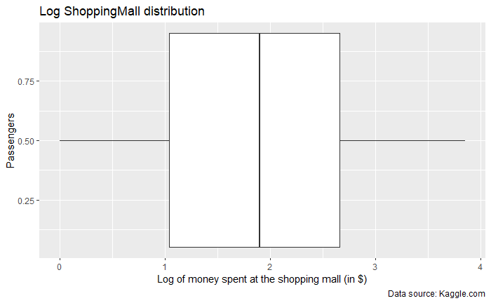

```r
ggplot(train_no_na) +
  geom_boxplot(mapping = aes(x=Transported, y=log10(ShoppingMall))) +
  coord_flip() +
        labs(x = "Passengers",
           y = "Log of money spent at the shopping mall (in $)",
           title = "Log ShoppingMall distribution",
           caption = "Data source: Kaggle.com")
```

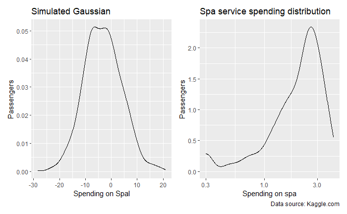

```r
spa <- log10(train_no_na$Spa)
simulatedGaussianSp <- tibble(spending=rnorm(n = 1000,
                        mean=mean(spa),
                        sd = sd(spa)))

simulatedGaussianSp %>%
  ggplot()+ geom_density(aes(x=spending)) + labs(x = "Spending on Spal",
                      y = "Passengers", title="Simulated Gaussian") +
  ggplot(train_no_na,mapping = aes(x=spa)) +
                 geom_density() +
                 labs(x = "Spending on spa",
                      y = "Passengers",
                      title = "Spa service spending distribution",
                      caption = "Data source: Kaggle.com") +
                scale_x_log10()
```

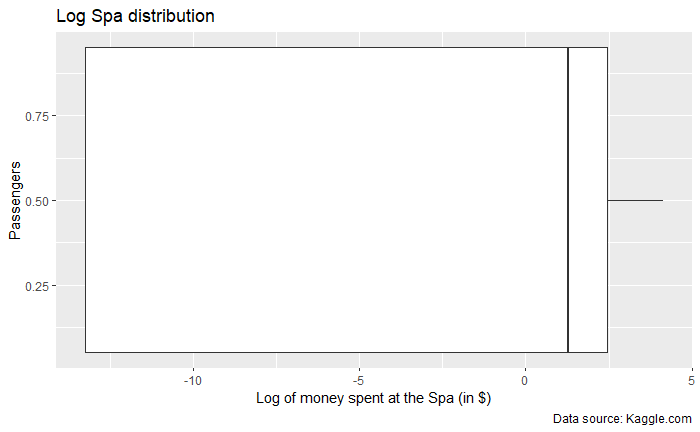

```r
ggplot(train_no_na) +
  geom_boxplot(mapping = aes(x=Transported, y=log10(Spa))) +
  coord_flip() +
        labs(x = "Passengers",
           y = "Log of money spent at the Spa (in $)",
           title = "Log Spa distribution",
           caption = "Data source: Kaggle.com")
```

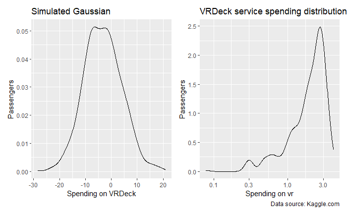

```r
vr <- log10(train_no_na$VRDeck)
simulatedGaussianV <- tibble(spending=rnorm(n = 1000,
                        mean=mean(vr),
                        sd = sd(vr)))

simulatedGaussianSp %>%
  ggplot()+ geom_density(aes(x=spending)) + labs(x = "Spending on VRDeck",
                      y = "Passengers", title="Simulated Gaussian") +
  ggplot(train_no_na,mapping = aes(x=vr)) +
                 geom_density() +
                 labs(x = "Spending on vr",
                      y = "Passengers",
                      title = "VRDeck service spending distribution",
                      caption = "Data source: Kaggle.com") +
                scale_x_log10()
```

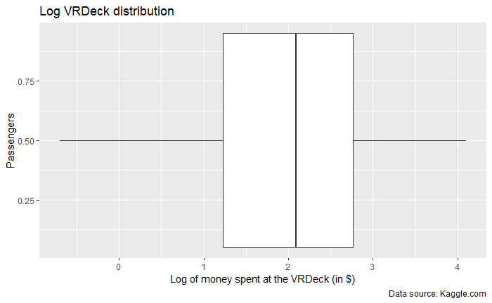

```r
ggplot(train_no_na) +
  geom_boxplot(mapping = aes(x=Transported, y=log10(VRDeck))) +
  coord_flip() +
        labs(x = "Passengers",
           y = "Log of money spent at the VRDeck (in $)",
           title = "Log VRDeck distribution",
           caption = "Data source: Kaggle.com")
```

```r
# skeweness test for age.
print("We tested the skenewess of age, to validate our visual indicators of positive skeweness")
```

```
[1] "We tested the skenewess of age, to validate our visual indicators of positive skeweness"
```

```r
skewness(train_no_na$Age)
```

```
[1] 0.9559636
```

```r
print("The test returns a value greater than 0, as expected.")
```

```
[1] "The test returns a value greater than 0, as expected."
```

Applying a log transformation we get distributions that are a bit more Gaussian in nature.

We will see if our models improve using log-transforms in the tuning phase.

We also verified the positive skeweness of age, justifying our imputation with the median instead of the mean value.

## Numerical correlations

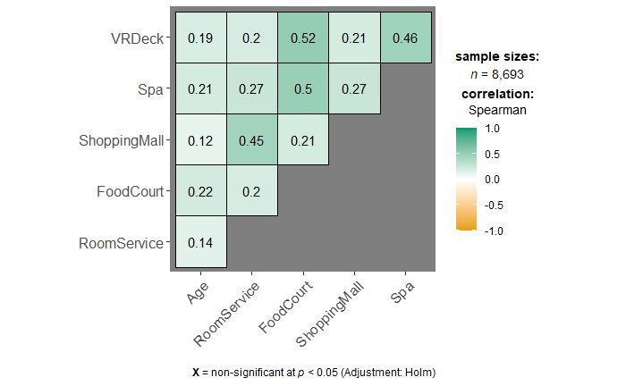

```r
ggcorrmat(
  data = train,
  cor.vars = c(Age,RoomService,FoodCourt,ShoppingMall,Spa,VRDeck),
  type = "spearman",
  ggtheme = ggplot2::theme_dark()
)
```

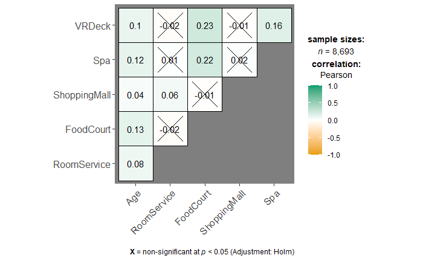

```r
ggcorrmat(
  data = train,
  cor.vars = c(Age,RoomService,FoodCourt,ShoppingMall,Spa,VRDeck),
  type = "pearson",
  ggtheme = ggplot2::theme_dark()
)
```

It seems from the spearman correlations, we have some non-linear relationships between amenities, this may make non-linear classifiers more effective for our data-sets, we will check these assumptions in the modelling phase.

## Linear extrapolation of amenities.

One of our initial ideas to reconstruct the missing values for age was to model it on the other variables with a linear regression. From the numerical correlations it already seemed improbable we would be able to do so.

We checked the scatter plot of age and the aggregated amenities to confirm our intuition:

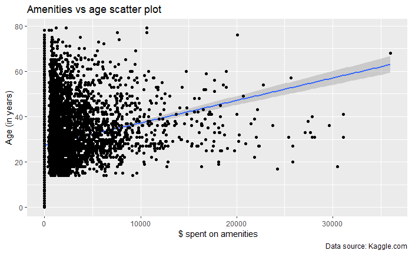

```r
ggplot(train, aes(Amenities, Age)) +
  geom_smooth(method='lm', formula= y~x)+
  geom_point() +
  labs( x = " $ spent on amenities",
        y = "Age (in years)",
        title = "Amenities vs age scatter plot",
        caption = "Data source: Kaggle.com")
```

Given this plot it did not really make sense to try linear modelling on the Age. As mentioned previously, we therefore decided to impute the missing age values with the median, which should help with the long tails we noticed in the distribution (as opposed to imputing with the mean value).

To apply linear regression we decided to extrapolate how each amenity contributes to the total, being sure there is a linear relationship in this case, and that the coefficients should all be (close to) one.

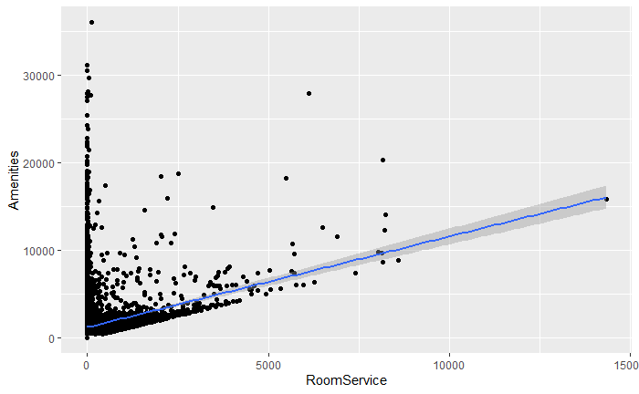

```r
ggplot(train_no_missing_amenities, aes(RoomService, Amenities)) +
  geom_point() +
  geom_smooth(method='lm', formula= y~x)
```

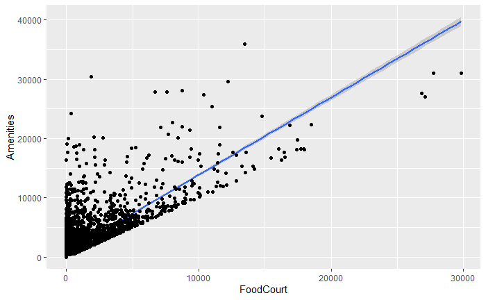

```r
ggplot(train_no_missing_amenities, aes(FoodCourt, Amenities)) +
  geom_smooth(method='lm', formula= y~x)+
  geom_point()
```

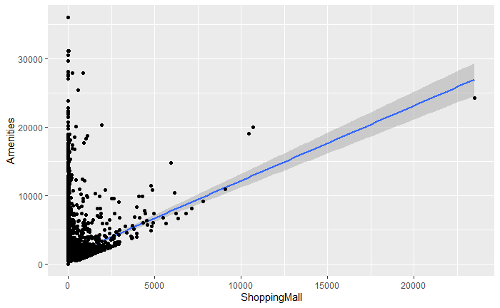

```r
ggplot(train_no_missing_amenities, aes(ShoppingMall, Amenities)) +
  geom_smooth(method='lm', formula= y~x)+
  geom_point()
```

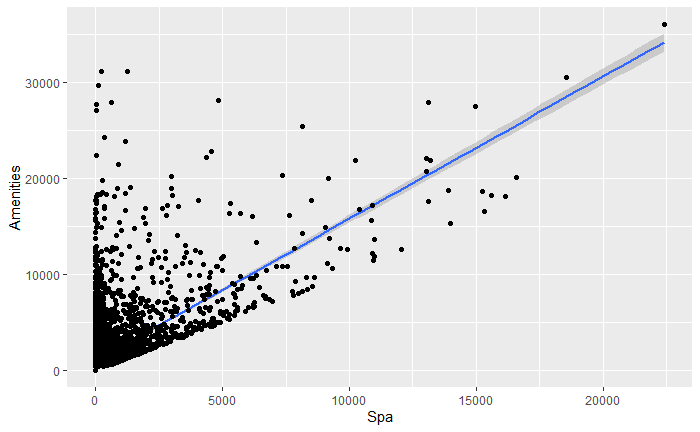

```r
ggplot(train_no_missing_amenities, aes(Spa, Amenities)) +
  geom_smooth(method='lm', formula= y~x)+
  geom_point()
```

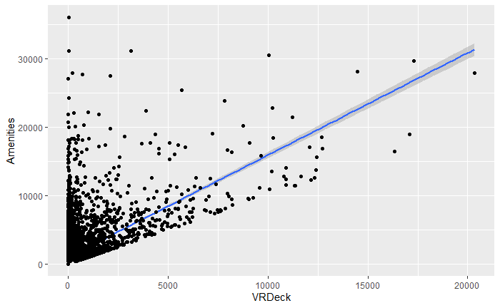

```r
ggplot(train_no_missing_amenities, aes(VRDeck, Amenities)) +
  geom_smooth(method='lm', formula= y~x)+
  geom_point()
```

```r
room_reg = lm(Amenities~RoomService,data= train_no_missing_amenities)
food_reg = lm(Amenities~FoodCourt,data= train_no_missing_amenities)
shopping_mall_reg = lm(Amenities~ShoppingMall,data= train_no_missing_amenities)
spa_reg = lm(Amenities~Spa,data= train_no_missing_amenities)
vr_reg = lm(Amenities~VRDeck,data= train_no_missing_amenities)


summary(room_reg)
```

```
Call:
lm(formula = Amenities ~ RoomService, data = train_no_missing_amenities)

Residuals:
   Min     1Q Median     3Q    Max
 -1449  -1178  -1128   -270  34680

Coefficients:
             Estimate Std. Error t value Pr(>|t|)
(Intercept) 1.178e+03  3.148e+01   37.42   <2e-16 ***
RoomService 1.037e+00  4.684e-02   22.13   <2e-16 ***
---
Signif. codes:  0 ‘***’ 0.001 ‘**’ 0.01 ‘*’ 0.05 ‘.’ 0.1 ‘ ’ 1

Residual standard error: 2706 on 8180 degrees of freedom
Multiple R-squared:  0.0565,    Adjusted R-squared:  0.05639
F-statistic: 489.9 on 1 and 8180 DF,  p-value: < 2.2e-16
```

```r
summary(food_reg)
```

```
Call:
lm(formula = Amenities ~ FoodCourt, data = train_no_missing_amenities)

Residuals:
    Min      1Q  Median      3Q     Max
-9107.2  -813.4  -813.4   132.3 27210.2

Coefficients:
             Estimate Std. Error t value Pr(>|t|)
(Intercept) 813.42482   21.12378   38.51   <2e-16 ***
FoodCourt     1.30692    0.01272  102.73   <2e-16 ***
---
Signif. codes:  0 ‘***’ 0.001 ‘**’ 0.01 ‘*’ 0.05 ‘.’ 0.1 ‘ ’ 1

Residual standard error: 1841 on 8180 degrees of freedom
Multiple R-squared:  0.5633,    Adjusted R-squared:  0.5633
F-statistic: 1.055e+04 on 1 and 8180 DF,  p-value: < 2.2e-16
```

```r
summary(shopping_mall_reg)
```

```
Call:
lm(formula = Amenities ~ ShoppingMall, data = train_no_missing_amenities)

Residuals:
   Min     1Q Median     3Q    Max
 -2713  -1220  -1136   -171  34767

Coefficients:
              Estimate Std. Error t value Pr(>|t|)
(Intercept)  1.220e+03  3.114e+01   39.18   <2e-16 ***
ShoppingMall 1.094e+00  5.212e-02   21.00   <2e-16 ***
---
Signif. codes:  0 ‘***’ 0.001 ‘**’ 0.01 ‘*’ 0.05 ‘.’ 0.1 ‘ ’ 1

Residual standard error: 2714 on 8180 degrees of freedom
Multiple R-squared:  0.05114,   Adjusted R-squared:  0.05103
F-statistic: 440.9 on 1 and 8180 DF,  p-value: < 2.2e-16
```

```r
summary(spa_reg)
```

```
Call:
lm(formula = Amenities ~ Spa, data = train_no_missing_amenities)

Residuals:
    Min      1Q  Median      3Q     Max
-7119.0  -951.1  -951.1    49.9 29823.7

Coefficients:
             Estimate Std. Error t value Pr(>|t|)
(Intercept) 951.12430   25.45600   37.36   <2e-16 ***
Spa           1.48085    0.02175   68.07   <2e-16 ***
---
Signif. codes:  0 ‘***’ 0.001 ‘**’ 0.01 ‘*’ 0.05 ‘.’ 0.1 ‘ ’ 1

Residual standard error: 2226 on 8180 degrees of freedom
Multiple R-squared:  0.3616,    Adjusted R-squared:  0.3615
F-statistic:  4634 on 1 and 8180 DF,  p-value: < 2.2e-16
```

```r
summary(vr_reg)
```

```
Call:
lm(formula = Amenities ~ VRDeck, data = train_no_missing_amenities)

Residuals:
   Min     1Q Median     3Q    Max
 -8955   -975   -975     73  34987

Coefficients:
             Estimate Std. Error t value Pr(>|t|)
(Intercept) 974.81039   25.98636   37.51   <2e-16 ***
VRDeck        1.49211    0.02332   63.98   <2e-16 ***
---
Signif. codes:  0 ‘***’ 0.001 ‘**’ 0.01 ‘*’ 0.05 ‘.’ 0.1 ‘ ’ 1

Residual standard error: 2274 on 8180 degrees of freedom
Multiple R-squared:  0.3335,    Adjusted R-squared:  0.3334
F-statistic:  4093 on 1 and 8180 DF,  p-value: < 2.2e-16
```

Unsurprisingly none of the single variable models fit well, the most interesting information we can extract from the models above is that spending on room service and the shopping mall accounts for a very small amount of the total spent on amenities.

```r
sanity_reg = lm(Amenities~RoomService + FoodCourt + ShoppingMall +
                  Spa + VRDeck,data= train_no_missing_amenities)
summary(sanity_reg)
```

```
Call:
lm(formula = Amenities ~ RoomService + FoodCourt + ShoppingMall +
    Spa + VRDeck, data = train_no_missing_amenities)

Residuals:
       Min         1Q     Median         3Q        Max
-9.376e-09 -1.600e-12 -1.300e-12 -1.200e-12  1.381e-08

Coefficients:
              Estimate Std. Error   t value Pr(>|t|)
(Intercept)  3.571e-11  2.695e-12 1.325e+01   <2e-16 ***
RoomService  1.000e+00  3.672e-15 2.724e+14   <2e-16 ***
FoodCourt    1.000e+00  1.533e-15 6.522e+14   <2e-16 ***
ShoppingMall 1.000e+00  4.074e-15 2.454e+14   <2e-16 ***
Spa          1.000e+00  2.135e-15 4.683e+14   <2e-16 ***
VRDeck       1.000e+00  2.242e-15 4.459e+14   <2e-16 ***
---
Signif. codes:  0 ‘***’ 0.001 ‘**’ 0.01 ‘*’ 0.05 ‘.’ 0.1 ‘ ’ 1

Residual standard error: 2.117e-10 on 8176 degrees of freedom
Multiple R-squared:      1, Adjusted R-squared:      1
F-statistic: 2.834e+29 on 5 and 8176 DF,  p-value: < 2.2e-16
```

As expected the multivariate regression explains almost the total of Amenities, with each coefficient equal to 1 (as it should be). Checking the residuals:

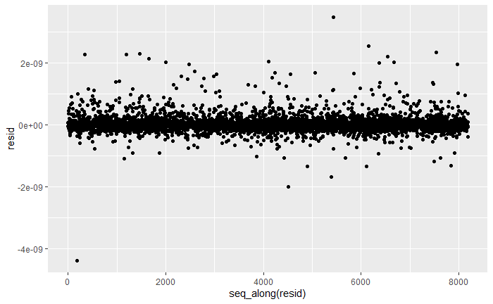

```r
train_withResid <-
  as.data.frame(train_no_missing_amenities) %>%
  add_residuals(sanity_reg)

train_withResid %>%
  ggplot()+
  geom_point(aes(
    x=seq_along(resid),
    y=resid))
```

We see no obvious pattern from the residuals and the mean is close to 0.

## Categorical variables:

Let’s now check how the categorical variables are distributed amongst their classes

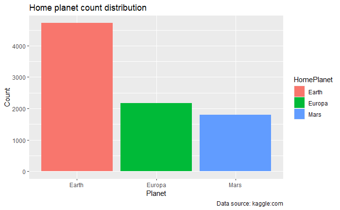

```r
train %>% ggplot(aes(x=HomePlanet,fill=HomePlanet)) +
                  geom_bar() +
                  labs(title = "Home planet count distribution",
                  x = "Planet",
                  y = "Count",
                  caption = "Data source: kaggle:com")
```

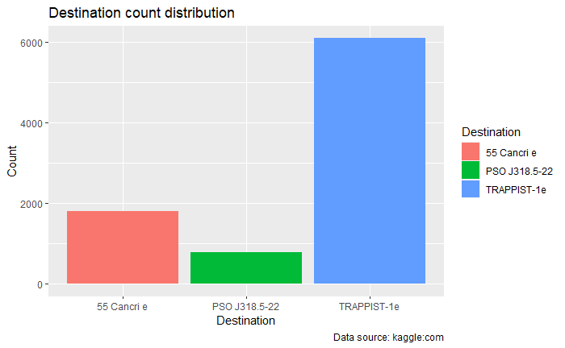

```r
train %>% ggplot(aes(x=Destination,fill=Destination)) +
                  geom_bar() +
                  labs(title = "Destination count distribution",
                  x = "Destination",
                  y = "Count",
                  caption = "Data source: kaggle:com")
```

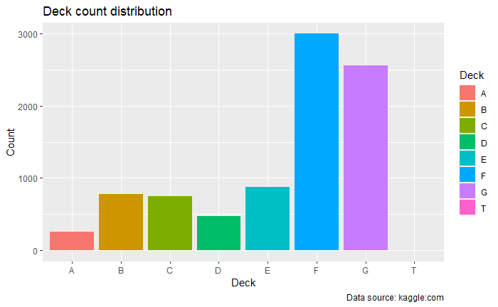

```r
train %>% ggplot(aes(x=Deck,fill=Deck)) +
                  geom_bar() +
                  labs(title = "Deck count distribution",
                  x = "Deck",
                  y = "Count",
                  caption = "Data source: kaggle:com")
```

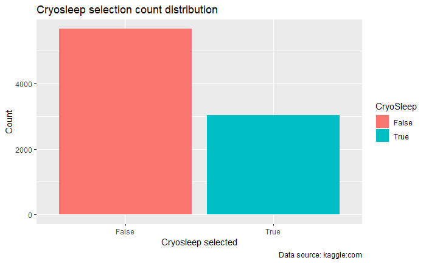

```r
train %>% mutate(CryoSleep = as.factor(CryoSleep)) %>%
  mutate (CryoSleep = recode(CryoSleep, "0" = "False", "1" = "True"))  %>%
  ggplot(aes(x=CryoSleep,fill=CryoSleep))+
                  geom_bar() +
                  labs(title = "Cryosleep selection count distribution",
                  x = "Cryosleep selected",
                  y = "Count",
                  caption = "Data source: kaggle:com")
```

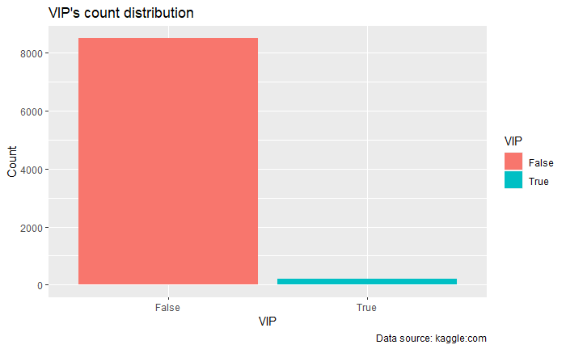

```r
train %>% mutate(VIP = as.factor(VIP)) %>%
  mutate (VIP = recode(VIP, "0" = "False", "1" = "True")) %>%
  ggplot(aes(x=VIP,fill=VIP)) +
                  geom_bar() +
                  labs(title = "VIP's count distribution",
                  x = "VIP",
                  y = "Count",
                  caption = "Data source: kaggle:com")
```

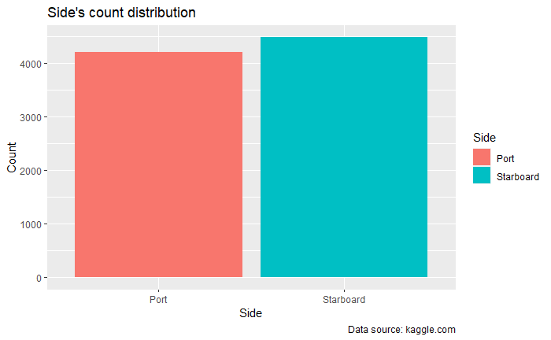

```r
train %>% mutate(Side = as.factor(Side)) %>%
          mutate (Side = recode(Side, "0" = "Port", "1" = "Starboard")) %>%
          ggplot(aes(x=Side, fill = Side)) +
          geom_bar() +
          labs(title = "Side's count distribution",
          x = "Side",
          y = "Count",
          caption = "Data source: kaggle.com")
```

```r
NA
NA
NA
```

- Most passengers boarded from Earth, but we have enough data on all origin planets.
- Most passengers are going to TRAPPIST-1e, but we have enough data on all destinations.
- Most passengers are on decks F and G, interestingly almost none is on deck T, it’s either a crew only area of the ship or dedicated to amenities.
- Roughly two thirds of the passengers chose not go into cryosleep.
- As expected we have very few VIP’s on board.
- The distribution between port and starboard accomodations is roughly balanced.

## Transported target.

In this section we will examine all of the dataset’s features in relation to our target, the transported status.

### Transported Target distribution, for known cases:

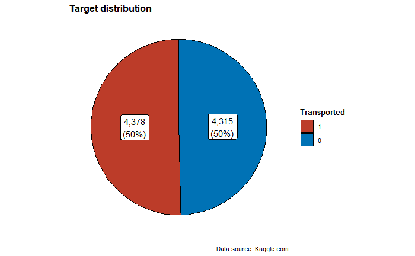

```r
 ggpiestats( data = train,
             x = Transported,
             label = "both",
             title = "Target distribution",
             legend.title = "Transported",
             caption = "Data source: Kaggle.com",
             results.subtitle = FALSE,
             package = "ggsci",
             palette = "default_nejm",
             )
```

The target variable is well balanced, we can therefore work with accuracy as our main metric, but we will also look at many other measures.

### Transported and categorical variables:

Let’s visualize the relationship between Transported and the categorical variables

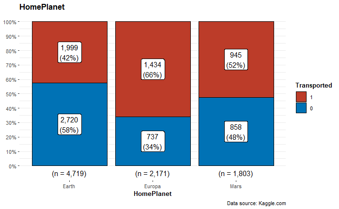

```r
ggbarstats(train,
           x=Transported,
           y=HomePlanet,
           results.subtitle = FALSE,
           label = "both",
           title = "HomePlanet",
           legend.title = "Transported",
           caption = "Data source: Kaggle.com",
           package = "ggsci",
           palette = "default_nejm")
```

[figure not shown]

```r
ggbarstats(train,
           x=Transported,
           y=Destination,
           results.subtitle = FALSE,
           label = "both",
           title = "Destination",
           legend.title = "Transported",
           caption = "Data source: Kaggle.com",
           package = "ggsci",
           palette = "default_nejm")
```

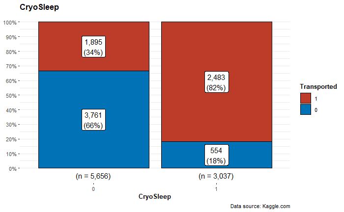

```r
ggbarstats(train,
           x=Transported,
           y=CryoSleep,
           results.subtitle = FALSE,
           label = "both",
           title = "CryoSleep",
           legend.title = "Transported",
           caption = "Data source: Kaggle.com",
           package = "ggsci",
           palette = "default_nejm")
```

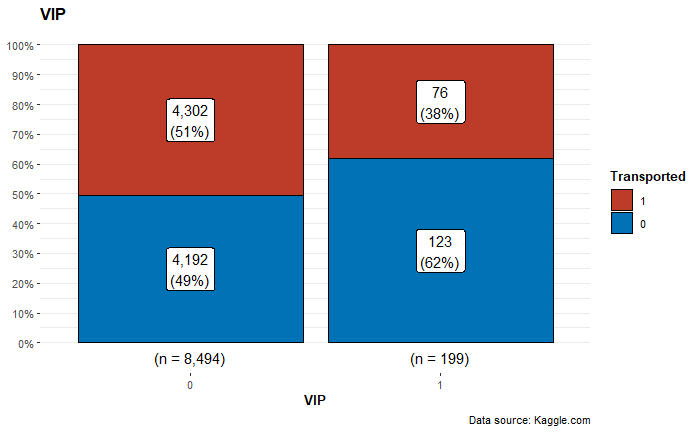

```r
ggbarstats(train,
           x=Transported,
           y=VIP,
           results.subtitle = FALSE,
           label = "both",
           title = "VIP",
           legend.title = "Transported",
           caption = "Data source: Kaggle.com",
           package = "ggsci",
           palette = "default_nejm")
```

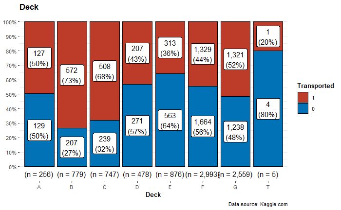

```r
ggbarstats(train,
           x=Transported,
           y=Deck,
           results.subtitle = FALSE,
           label = "both",
           title = "Deck",
           legend.title = "Transported",
           caption = "Data source: Kaggle.com",
           package = "ggsci",
           palette = "default_nejm")
```

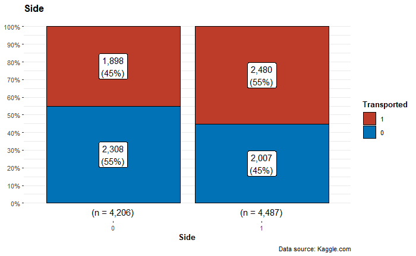

```r
ggbarstats(train,
           x=Transported,
           y=Side,
           results.subtitle = FALSE,
           label = "both",
           title = "Side",
           legend.title = "Transported",
           caption = "Data source: Kaggle.com",
           package = "ggsci",
           palette = "default_nejm")
```

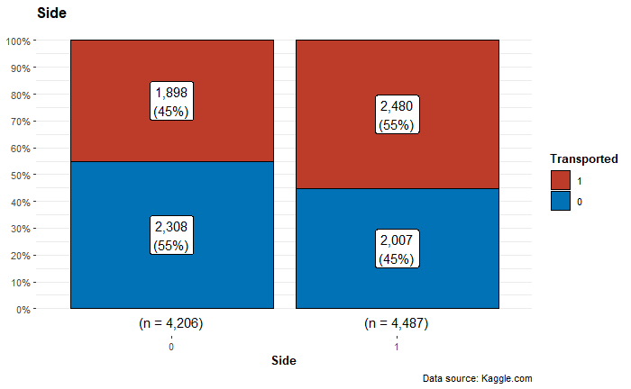

```r
ggbarstats(train,
           x=Transported,
           y=Side,
           results.subtitle = FALSE,
           label = "both",
           title = "Side",
           legend.title = "Transported",
           caption = "Data source: Kaggle.com",
           package = "ggsci",
           palette = "default_nejm")
```

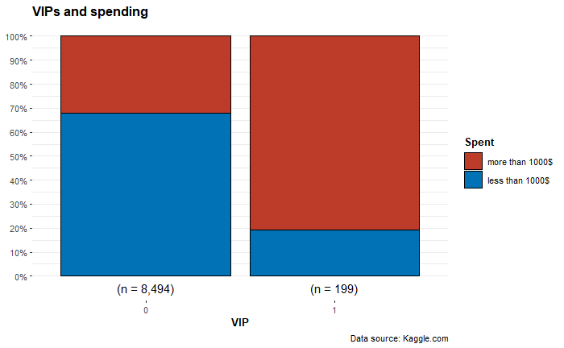

```r
train_graph <- train

train_graph <- train_graph %>% mutate(BinnedAmenities =
                                        cut(Amenities, breaks=c(0, 1000, 50000)))

levels(train_graph$BinnedAmenities) <- c("less than 1000$", "more than 1000$")

train_graph <- train_graph %>% mutate(BinnedAges =
                                        cut(Age, breaks=c(0, 20, 40, 90)))

lab <- format(date_breaks, "%d - %d")

vip = ggbarstats(train_graph,
           x=BinnedAmenities,
           y=VIP,
           results.subtitle = FALSE,
           label = "both",
           title = "VIPs and spending",
           legend.title = "Spent",
           caption = "Data source: Kaggle.com",
           package = "ggsci",
           palette = "default_nejm")

age = ggbarstats(train_graph,
           x=BinnedAmenities,
           y=BinnedAges,
           results.subtitle = FALSE,
           label = "both",
           title = "Age and spending",
           caption = "Data source: Kaggle.com",
           package = "ggsci",
           palette = "default_nejm")

delete_layers(vip, "GeomLabel")
```

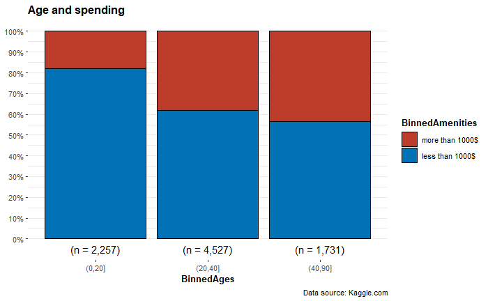

```r
delete_layers(age, "GeomLabel")
```

From the plots we noticed it seems more likely to be transported for passengers from Europa, more likely to be transported for passengers going to 55 Cancri, and for VIP’s, also very likely to be transported if you’re in cryosleep, if your side is starboard, and if you are on decks B or C.

Let’s see if these intuitions are corroborate by Anova Tests:

#### Anova tests

```r
# for all home planets
car::Anova(lm(Transported~HomePlanet,
              data=train))
```

```
Anova Table (Type II tests)

Response: Transported
            Sum Sq   Df F value    Pr(>F)
HomePlanet   84.42    2  175.61 < 2.2e-16 ***
Residuals  2088.72 8690
---
Signif. codes:  0 ‘***’ 0.001 ‘**’ 0.01 ‘*’ 0.05 ‘.’ 0.1 ‘ ’ 1
```

```r
# is Europa  the only reason for the mean being different?
train_test_home <- train %>%
  filter(HomePlanet!='Europa')
car::Anova(lm(Transported~HomePlanet,
              data = train_test_home))
```

```
Anova Table (Type II tests)

Response: Transported
            Sum Sq   Df F value    Pr(>F)
HomePlanet   13.18    1  53.651 2.683e-13 ***
Residuals  1601.91 6520
---
Signif. codes:  0 ‘***’ 0.001 ‘**’ 0.01 ‘*’ 0.05 ‘.’ 0.1 ‘ ’ 1
```

```r
# for all destinations
car::Anova(lm(Transported~Destination,
              data=train))
```

```
Anova Table (Type II tests)

Response: Transported
             Sum Sq   Df F value    Pr(>F)
Destination   26.39    2  53.412 < 2.2e-16 ***
Residuals   2146.75 8690
---
Signif. codes:  0 ‘***’ 0.001 ‘**’ 0.01 ‘*’ 0.05 ‘.’ 0.1 ‘ ’ 1
```

```r
# is 55 Cancri the only reason for the mean being different?
train_test_destination <- train %>%
  filter(Destination!='55 Cancri e')
car::Anova(lm(Transported~Destination,
              data = train_test_destination))
```

```
Anova Table (Type II tests)

Response: Transported
            Sum Sq   Df F value  Pr(>F)
Destination    0.7    1  2.8137 0.09351 .
Residuals   1718.5 6891
---
Signif. codes:  0 ‘***’ 0.001 ‘**’ 0.01 ‘*’ 0.05 ‘.’ 0.1 ‘ ’ 1
```

```r
# Interestingly, at alpha = 0.05 yes.



car::Anova(lm(Transported~CryoSleep,
              data=train))
```

```
Anova Table (Type II tests)

Response: Transported
          Sum Sq   Df F value    Pr(>F)
CryoSleep  460.1    1  2334.3 < 2.2e-16 ***
Residuals 1713.0 8691
---
Signif. codes:  0 ‘***’ 0.001 ‘**’ 0.01 ‘*’ 0.05 ‘.’ 0.1 ‘ ’ 1
```

```r
car::Anova(lm(Transported~VIP,
              data=train))
```

```
Anova Table (Type II tests)

Response: Transported
           Sum Sq   Df F value    Pr(>F)
VIP          3.02    1  12.083 0.0005113 ***
Residuals 2170.12 8691
---
Signif. codes:  0 ‘***’ 0.001 ‘**’ 0.01 ‘*’ 0.05 ‘.’ 0.1 ‘ ’ 1
```

```r
car::Anova(lm(Transported~Deck,
              data=train))
```

```
Anova Table (Type II tests)

Response: Transported
           Sum Sq   Df F value    Pr(>F)
Deck        97.34    7  58.179 < 2.2e-16 ***
Residuals 2075.80 8685
---
Signif. codes:  0 ‘***’ 0.001 ‘**’ 0.01 ‘*’ 0.05 ‘.’ 0.1 ‘ ’ 1
```

```r
car::Anova(lm(Transported~Side,
              data=train))
```

```
Anova Table (Type II tests)

Response: Transported
           Sum Sq   Df F value    Pr(>F)
Side        22.34    1  90.284 < 2.2e-16 ***
Residuals 2150.79 8691
---
Signif. codes:  0 ‘***’ 0.001 ‘**’ 0.01 ‘*’ 0.05 ‘.’ 0.1 ‘ ’ 1
```

```r
car::Anova(lm(Transported~BinnedAges,
              data=train_graph))
```

```
Anova Table (Type II tests)

Response: Transported
           Sum Sq   Df F value    Pr(>F)
BinnedAges   10.9    2  21.913 3.217e-10 ***
Residuals  2117.8 8512
---
Signif. codes:  0 ‘***’ 0.001 ‘**’ 0.01 ‘*’ 0.05 ‘.’ 0.1 ‘ ’ 1
```

```r
# is the difference only caused by young people being unable to spend much?
train_graph_anova <- train_graph %>%
  filter(BinnedAges!= "(0,20]")
car::Anova(lm(Transported~BinnedAges,
              data = train_graph_anova))
```

```
Anova Table (Type II tests)

Response: Transported
           Sum Sq   Df F value Pr(>F)
BinnedAges    0.6    1  2.4104 0.1206
Residuals  1560.4 6256
```

```r
# interestingly that seems to be mostly the case.
```

All tests corroborate our intuition, we therefore assume the anomaly hit closer to decks B and C, which were more populated by people from Europa, going to Cancri e and / or VIP, it’s also very likely it hit the area of the ship hosting at least some of the rooms dedicated to cryosleep, finally as one would expect people closer to the external area of the hull, hence starboard were more likely to be hit.

After consulting our supervisor, we also excluded the most obvious class for HomePlanet and Destination, we found that the mean is strongly significantly different for all home planets, but the same cannot be said for destinations, in that case Cancri 55 e is really the most important factor for the three destinations having different transported means.

We also checked how passengers, their home planets and destinations, were distributed on the ship:

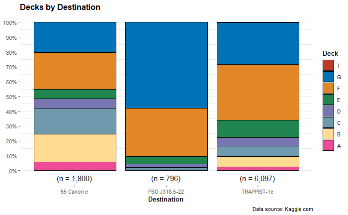

```r
deck_plot_h <-ggbarstats(train,
            x=Deck,
            y=HomePlanet,
            results.subtitle = FALSE,
            label = "percentage",
            bf.message = FALSE,
            title = "Decks by HomePlanet",
            legend.title = "Deck",
            caption = "Data source: Kaggle.com",
            package = "ggsci",
            palette = "default_nejm")


deck_plot_d <-ggbarstats(train,
            x=Deck,
            y=Destination,
            results.subtitle = FALSE,
            label = "percentage",
            bf.message = FALSE,
            title = "Decks by Destination",
            legend.title = "Deck",
            caption = "Data source: Kaggle.com",
            package = "ggsci",
            palette = "default_nejm")


delete_layers(deck_plot_d, "GeomLabel")
```

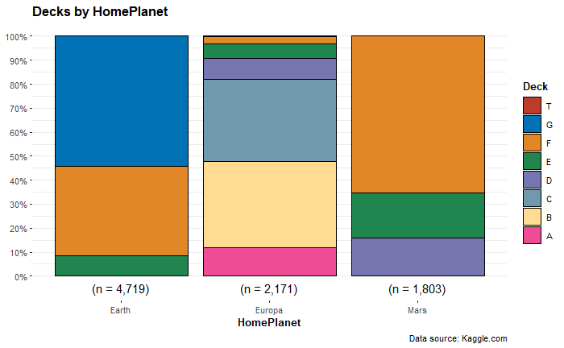

```r
delete_layers(deck_plot_h, "GeomLabel")
```

### Numerical variables and the target

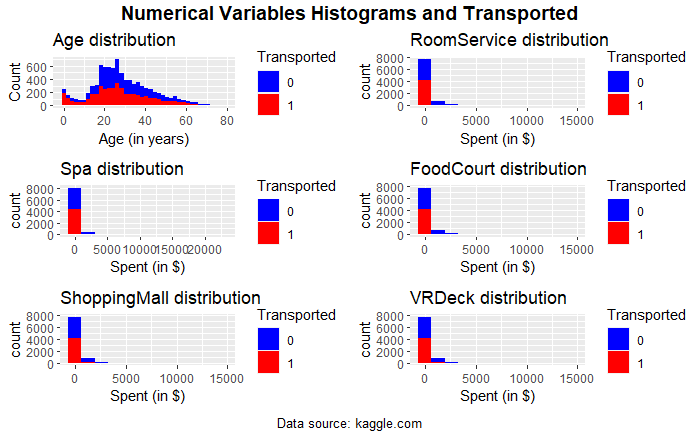

```r
train_amenities_no_na <- train

## age plot
age_plot <-
  ggplot(train_amenities_no_na,mapping =
           aes(x=Age,fill = as.factor(Transported))) +
  geom_histogram(bins = 40) +
  labs(title = "Age distribution",
       x = "Age (in years)",
       y = "Count",
       fill='Transported') +
  scale_fill_manual(values = c("blue", "red"))

## Amenities plots
roomservice_plot <-
  ggplot(train_amenities_no_na,
         aes(x = RoomService, fill = as.factor(Transported))) +
  geom_histogram(bins = 12) +
  labs(title="RoomService distribution",
       x = "Spent (in $)",
       fill='Transported') +
  scale_fill_manual(values = c("blue", "red"))


## Spa plot
spa_plot <-
  ggplot(train_amenities_no_na,
         aes(x = Spa, fill = as.factor(Transported))) +
  geom_histogram(bins = 12) +
  labs(title="Spa distribution",
       x = "Spent (in $)",
       fill='Transported') +
  scale_fill_manual(values = c("blue", "red"))


foodcourt_plot <-
  ggplot(train_amenities_no_na,
         aes(x = RoomService, fill = as.factor(Transported))) +
  geom_histogram(bins = 12) +
  labs(title="FoodCourt distribution",
       x = "Spent (in $)",
       fill='Transported') +
  scale_fill_manual(values = c("blue", "red"))


shoppingmall_plot <-
  ggplot(train_amenities_no_na,
         aes(x = RoomService, fill = as.factor(Transported))) +
    geom_histogram(bins = 12)  +
    labs(title="ShoppingMall distribution",
       x = "Spent (in $)",
       fill='Transported') +
    scale_fill_manual(values = c("blue", "red"))


vrdeck_plot <-
  ggplot(train_amenities_no_na,
         aes(x = RoomService, fill= as.factor(Transported))) +
  geom_histogram(bins = 12)  +
  labs(title="VRDeck distribution",
       x = "Spent (in $)",
       fill='Transported') +
  scale_fill_manual(values = c("blue", "red"))


figure <- ggarrange(age_plot, roomservice_plot, spa_plot, foodcourt_plot,
          shoppingmall_plot, vrdeck_plot,
           ncol = 2, nrow = 3)

annotate_figure(figure,
               top = text_grob("Numerical Variables Histograms and Transported",
                               face = "bold", size = 14),
               bottom = text_grob("Data source: kaggle.com", size = 10))
```

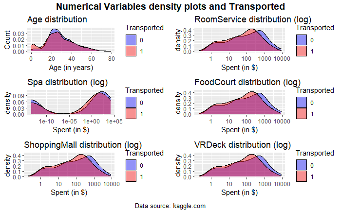

```r
# creating distributions plots

train_no_0 <- filter(train,  RoomService > 0 , FoodCourt > 0, ShoppingMall > 0,
                     Spa > 0, VRDeck > 0 )

## age plot
age_plot <-  ggplot(train,mapping = aes(x=Age,fill = as.factor(Transported))) +
             geom_density(alpha=0.4) +
             labs(title = "Age distribution",
                  x = "Age (in years)",
                  y = "Count",
                  fill='Transported')+
              scale_fill_manual(values = c("blue", "red"))

## Amenities plots
## room service plot
roomservice_plot <-
  ggplot(train_no_0, aes(x = RoomService, fill = as.factor(Transported))) +
  geom_density(alpha=0.4) +
  scale_x_log10() +
  labs(title="RoomService distribution (log)",
       x = "Spent (in $)",
       fill='Transported')+
       scale_fill_manual(values = c("blue", "red"))



## Spa plot
spa_plot <-
  ggplot(train_no_0, aes(x = Spa, fill = as.factor(Transported))) +
  geom_density(alpha=0.4) +
  scale_x_log10() +
  labs(title="Spa distribution (log)",
       x = "Spent (in $)",
       fill='Transported') +
       scale_fill_manual(values = c("blue", "red"))

foodcourt_plot <-
  ggplot(train_no_0, aes(x = RoomService, fill = as.factor(Transported))) +
  geom_density(alpha=0.4) +
  scale_x_log10() +
  labs(title="FoodCourt distribution (log)",
       x = "Spent (in $)",
       fill='Transported')+
       scale_fill_manual(values = c("blue", "red"))

shoppingmall_plot <-
  ggplot(train_no_0, aes(x = RoomService, fill = as.factor(Transported))) +
  geom_density(alpha=0.4) +
  scale_x_log10() +
  labs(title="ShoppingMall distribution (log)",
       x = "Spent (in $)",
       fill='Transported')+
       scale_fill_manual(values = c("blue", "red"))

vrdeck_plot <-
  ggplot(train_no_0, aes(x = RoomService, fill= as.factor(Transported))) +
  geom_density(alpha=0.4) +
  scale_x_log10() +
  labs(title="VRDeck distribution (log)",
       x = "Spent (in $)",
       fill='Transported')+
       scale_fill_manual(values = c("blue", "red"))


 # plotting all plots
figure <- ggarrange(age_plot, roomservice_plot, spa_plot, foodcourt_plot,
          shoppingmall_plot, vrdeck_plot,
           ncol = 2, nrow = 3)


annotate_figure(figure,
               top = text_grob("Numerical Variables density plots and Transported",
                               face = "bold", size = 14),
               bottom = text_grob("Data source: kaggle.com", size = 10))
```

Especially for people spending a lot of money (and hence time) at the amenities, and in particular at the spa, the chances of being transported is lower.

Our hypothesis is these amenities are not in the area of the ship with which the anomaly collided.

There seems to be little relation between age and being transported, although people between 20 and 40 seem to be less likely to be transported, from our age analysis to decide how to impute missing values, we know there are more big spenders than average in this age bracket, that could be a reason for this behavior.

# Modelling

In this chapter we will discuss our modelling on transported, the target variable. Since transported is a binary variables, classification models are appropriate. We decide to start with a baseline logistic regression, to see how the most common model would perform, to then expand to random forests. Given some non-linear relationships we found in the previous analysis, we expect random forest to perform better.

## Modelling Transported

As usual we work on a separate dataset:

```r
train_transported <- train
test_transported <- test
```

Imputations for the Transported modelling, ensuring there are no missing values in the features of interest, we also selected the features that made the most sense to us, after our exploratory analysis.

```r
# counting NA values
sapply(train_transported, function(x) sum(is.na(x)))
```

```
 PassengerId      GroupId IndividualId   HomePlanet    CryoSleep         Deck   RoomNumber         Side
           0            0            0            0            0            0          199            0
 Destination          Age          VIP  RoomService    FoodCourt ShoppingMall          Spa       VRDeck
           0            0            0            0            0            0            0            0
   Amenities    FirstName     LastName  Transported
           0          200          200            0
```

```r
sum(is.na(train_transported))
```

```
[1] 599
```

```r
# Filling NA numeric variables with the mean, safety measure in case some missing
# values were left from the amenities imputation via KNN.

train_transported$RoomService[is.na(train_transported$RoomService)] <-
  mean(train_transported$RoomService, na.rm = TRUE)

test_transported$RoomService[is.na(test_transported$RoomService)] <-
  mean(test_transported$RoomService, na.rm = TRUE)

train_transported$FoodCourt[is.na(train_transported$FoodCourt)] <-
  mean(train_transported$FoodCourt, na.rm = TRUE)

test_transported$FoodCourt[is.na(test_transported$FoodCourt)] <-
  mean(test_transported$FoodCourt, na.rm = TRUE)

train_transported$ShoppingMall[is.na(train_transported$ShoppingMall)] <-
  mean(train_transported$ShoppingMall, na.rm = TRUE)

test_transported$ShoppingMall[is.na(test_transported$ShoppingMall)] <-
  mean(test_transported$ShoppingMall, na.rm = TRUE)

train_transported$Spa[is.na(train_transported$Spa)] <-
  mean(train_transported$Spa, na.rm = TRUE)
test_transported$Spa[is.na(test_transported$Spa)] <-
  mean(test_transported$Spa, na.rm = TRUE)

train_transported$VRDeck[is.na(train_transported$VRDeck)] <-
  mean(train_transported$VRDeck, na.rm = TRUE)

test_transported$VRDeck[is.na(test_transported$VRDeck)] <-
  mean(test_transported$VRDeck, na.rm = TRUE)


# removing irrelevant columns
train_transported <-
  subset( train_transported, select = c(-FirstName,  -RoomNumber, -GroupId,
                                        - IndividualId, -LastName ,-Amenities,
                                        -PassengerId))

test_transported <-
  subset( test_transported, select = c(-FirstName,  -RoomNumber, -GroupId,
                                       -IndividualId, -LastName,-Amenities,
                                       -PassengerId))


#checking remaining missing values
sapply(train_transported, function(x) sum(is.na(x)))
```

```
  HomePlanet    CryoSleep         Deck         Side  Destination          Age          VIP  RoomService
           0            0            0            0            0            0            0            0
   FoodCourt ShoppingMall          Spa       VRDeck  Transported
           0            0            0            0            0
```

```r
sapply(test_transported, function(x) sum(is.na(x)))
```

```
  HomePlanet    CryoSleep         Deck         Side  Destination          Age          VIP  RoomService
           0            0            0            0            0            0            0            0
   FoodCourt ShoppingMall          Spa       VRDeck
           0            0            0            0
```

## Training and validation datasets:

Train-test-split, since we only have the training set, we are using part of it as a validation dataset.

```r
sample <- sample(c(TRUE, FALSE), nrow(train_transported),
                 replace=TRUE, prob=c(0.7,0.3))
train_data  <- train_transported[sample, ]
test_data   <- train_transported[!sample, ]
train.control <- trainControl(method = "cv", number = 10)
```

## Logistic regression

we proceed to train the logistic regression on our basic setup:

```r
# training a logistic regression model with most important features
glm_fit <- glm(formula=Transported~., data= train_data, family="binomial")
summary(glm_fit)
```

```
Call:
glm(formula = Transported ~ ., family = "binomial", data = train_data)

Deviance Residuals:
    Min       1Q   Median       3Q      Max
-2.7308  -0.7198   0.0000   0.7418   4.4200

Coefficients:
                           Estimate Std. Error z value Pr(>|z|)
(Intercept)              -1.228e+00  3.461e-01  -3.548 0.000388 ***
HomePlanetEuropa          1.874e+00  2.655e-01   7.058 1.69e-12 ***
HomePlanetMars            5.804e-01  1.094e-01   5.305 1.13e-07 ***
CryoSleep                 1.339e+00  9.312e-02  14.379  < 2e-16 ***
DeckB                     1.550e+00  2.935e-01   5.282 1.28e-07 ***
DeckC                     2.100e+00  3.071e-01   6.839 7.95e-12 ***
DeckD                     1.134e+00  3.240e-01   3.499 0.000467 ***
DeckE                     6.901e-01  3.274e-01   2.108 0.035062 *
DeckF                     1.223e+00  3.313e-01   3.692 0.000222 ***
DeckG                     9.030e-01  3.419e-01   2.641 0.008266 **
DeckT                    -7.633e-01  1.530e+00  -0.499 0.617749
Side                      5.689e-01  6.739e-02   8.442  < 2e-16 ***
DestinationPSO J318.5-22 -3.217e-01  1.320e-01  -2.438 0.014772 *
DestinationTRAPPIST-1e   -3.709e-01  9.386e-02  -3.951 7.78e-05 ***
Age                      -5.059e-03  2.434e-03  -2.078 0.037679 *
VIP                      -3.050e-01  3.088e-01  -0.988 0.323321
RoomService              -1.382e-03  1.005e-04 -13.747  < 2e-16 ***
FoodCourt                 4.694e-04  4.365e-05  10.756  < 2e-16 ***
ShoppingMall              5.250e-04  7.954e-05   6.600 4.11e-11 ***
Spa                      -1.816e-03  1.132e-04 -16.034  < 2e-16 ***
VRDeck                   -1.647e-03  1.104e-04 -14.923  < 2e-16 ***
---
Signif. codes:  0 ‘***’ 0.001 ‘**’ 0.01 ‘*’ 0.05 ‘.’ 0.1 ‘ ’ 1

(Dispersion parameter for binomial family taken to be 1)

    Null deviance: 8438.3  on 6086  degrees of freedom
Residual deviance: 5437.4  on 6066  degrees of freedom
AIC: 5479.4

Number of Fisher Scoring iterations: 7
```

```r
# testing on the validation set
testPred <- glm_fit %>% augment(new_data=test_data,type.predict = "response")
testPred <- testPred %>% mutate(binaryPred = as.numeric(.fitted>0.5))
testPred %>% summarise(accuracy=mean(binaryPred==Transported))
```

| accuracy |
| --- |
| 0.7833087 |

It’s interesting to note VIP does not seem to be very relevant, after discussing this with our team supervised, we believe most of the explainability coming from VIP has already been covered by the amenities, i.e. the feature is interesting only because of it’s relationship with how often VIP’s use amenities and were therefore less likely to be on the decks of the ship hit the hardest. The remaining information contained in the feature seems to be of little relevance.

Note also that the sample start to become very small since the original number of VIP’s was small to begin with and we are already factoring in the heavy spenders with the amenities, leaving very few data points.

We are also implementing a cross validation with 10 splits, to ensure we get a robust result.

```r
fitControl <- trainControl(method="cv",number= 10, savePredictions = T)

model_cv <- train(as.factor(Transported) ~ ., data=train_transported,
                  method="glm", family="binomial", trControl = fitControl)

model_cv
```

```
Generalized Linear Model

8693 samples
  12 predictor
   2 classes: '0', '1'

No pre-processing
Resampling: Cross-Validated (10 fold)
Summary of sample sizes: 7824, 7823, 7824, 7825, 7824, 7823, ...
Resampling results:

  Accuracy   Kappa
  0.7890246  0.5779289
```

The results are very similar. We already obtain quite a good score with our basic logistic regression.

## Tuning the logistic regression

We tried tuning it to see if using scaled features for amenities or adding / removing some columns of interest would yield a better score:

The first step was to check the variable importance according to our basic logistic regression model:

```r
importance <- as.data.frame(caret::varImp(glm_fit, scale=TRUE))
importance <- data.frame(overall = importance$Overall,
           names   = rownames(importance))
importance[order(importance$overall,decreasing = T),]
```

|  | overall | names |
| --- | --- | --- |
| 19 | 16.0339089 | Spa |
| 20 | 14.9229401 | VRDeck |
| 3 | 14.3793206 | CryoSleep |
| 16 | 13.7474543 | RoomService |
| 17 | 10.7555179 | FoodCourt |
| 11 | 8.4418776 | Side |
| 1 | 7.0581438 | HomePlanetEuropa |
| 5 | 6.8393647 | DeckC |
| 18 | 6.6001468 | ShoppingMall |
| 2 | 5.3050630 | HomePlanetMars |

[output cut: 10 more lines]

We noticed Age and VIP are not that relevant and tried excluding them:

```r
train_transported_2 <- subset( train_transported, select = c(-Age,  -VIP))
test_transported_2 <- subset( test_transported, select = c(-Age, -VIP))


model_cv_2 <- train(as.factor(Transported) ~ ., data=train_transported_2,
                    method="glm", family="binomial", trControl = fitControl)

model_cv_2
```

```
Generalized Linear Model

8693 samples
  10 predictor
   2 classes: '0', '1'

No pre-processing
Resampling: Cross-Validated (10 fold)
Summary of sample sizes: 7824, 7824, 7823, 7824, 7824, 7823, ...
Resampling results:

  Accuracy   Kappa
  0.7902859  0.5804456
```

We get very similar, and in most runs slightly improved results. To us this is an indicator that the logistic regression cannot capture all the complexities in the dataset.

```r
scalable = c("RoomService", "FoodCourt", "ShoppingMall", "Spa", "VRDeck")
train_transported_scaled <- train_transported %>% mutate_each(list(~log(1 + .)),
                                                              scalable)
```

```
Note: Using an external vector in selections is ambiguous.
i Use `all_of(scalable)` instead of `scalable` to silence this message.
i See <https://tidyselect.r-lib.org/reference/faq-external-vector.html>.
```

```r
model_cv_3 <- train(as.factor(Transported) ~ ., data=train_transported_scaled,
                    method="glm", family="binomial", trControl = fitControl)

model_cv_3
```

```
Generalized Linear Model

8693 samples
  12 predictor
   2 classes: '0', '1'

No pre-processing
Resampling: Cross-Validated (10 fold)
Summary of sample sizes: 7824, 7823, 7823, 7824, 7824, 7823, ...
Resampling results:

  Accuracy   Kappa
  0.7760236  0.5519151
```

We also checked possible changes in variable importance:

```r
glm_fit_scaled <- glm(formula=Transported~., data= train_transported_scaled,
                      family="binomial")

importance <- as.data.frame(caret::varImp(glm_fit_scaled, scale=TRUE))
importance <- data.frame(overall = importance$Overall,
           names   = rownames(importance))
importance[order(importance$overall,decreasing = T),]
```

|  | overall | names |
| --- | --- | --- |
| 19 | 20.1755282 | Spa |
| 20 | 19.4995817 | VRDeck |
| 16 | 16.6866023 | RoomService |
| 3 | 12.9827177 | CryoSleep |
| 17 | 10.9966460 | FoodCourt |
| 11 | 9.5534237 | Side |
| 18 | 8.2312437 | ShoppingMall |
| 1 | 7.6000140 | HomePlanetEuropa |
| 5 | 4.8980818 | DeckC |
| 13 | 4.7956059 | DestinationTRAPPIST-1e |

[output cut: 10 more lines]

```r
NA
```

We don’t observe major differences, in particular we were curious about cryosleep, which to the eye-test seems the most relevant feature, but scaling manually to be sure we are measuring values on similar scales confirms that the logistic regression model finds many of the amenities to be the most important features to determine the passenger’s transportation status.

## Random Forest

Our assumption is the random forest will perform better, we tried selecting a few different values for the number of trees and the best setup seems to be around 1000 trees, although similar accuracies are already reached with 200 trees. The galactic data science team luckily has enough computing power to optimize.

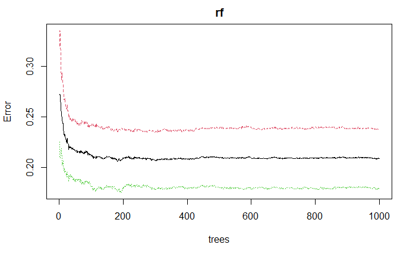

```r
set.seed(42)
rf <- randomForest(as.factor(Transported) ~ .,
                   data = train_data,
                   ntree = 1000,
                   importance = T)

plot(rf)
```

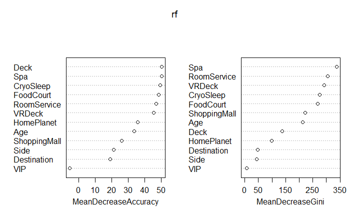

```r
varImpPlot(rf, sort=TRUE)
```

```r
rf
```

```
Call:
 randomForest(formula = as.factor(Transported) ~ ., data = train_data,      ntree = 1000, importance = T)
               Type of random forest: classification
                     Number of trees: 1000
No. of variables tried at each split: 3

        OOB estimate of  error rate: 20.88%
Confusion matrix:
     0    1 class.error
0 2327  729   0.2385471
1  542 2489   0.1788189
```

The feature importance plot is very similar to what we obtain with the logistic regression, reinforcing our conclusions on amenitites being more important predictors compared to what one might think.

## Random forest results

Our results are summarized in this confusion matrix, most of the common evaluation metrics are provided, and there is no big difference between which one we may choose, as expected from a balanced dataset.

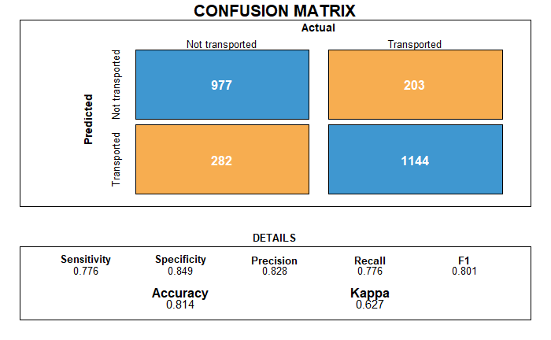

```r
# creating evaluation matrix
prediction <-predict(rf, test_data, "response")
prediction <- factor(prediction,levels=c(0,1))

cm <- confusionMatrix(prediction, as.factor(test_data$Transported))

draw_confusion_matrix(cm)
```

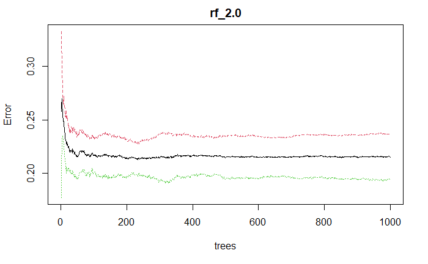

```r
rf_2.0 <- randomForest(as.factor(Transported) ~ CryoSleep + FoodCourt + Spa + Deck + VRDeck + RoomService + Age + HomePlanet,
                   data = train_data,
                   ntree = 1000,
                   importance = T)

plot(rf_2.0)
```

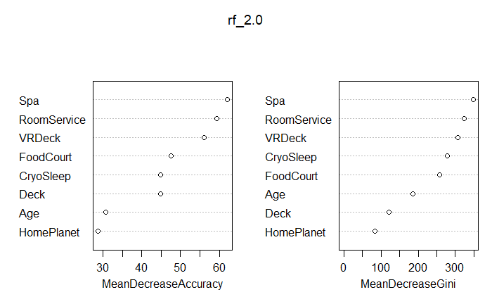

```r
varImpPlot(rf_2.0, sort=TRUE)
```

```r
rf_2.0
```

```
Call:
 randomForest(formula = as.factor(Transported) ~ CryoSleep + FoodCourt +      Spa + Deck + VRDeck + RoomService + Age + HomePlanet, data = train_data,      ntree = 1000, importance = T)
               Type of random forest: classification
                     Number of trees: 1000
No. of variables tried at each split: 2

        OOB estimate of  error rate: 21.52%
Confusion matrix:
     0    1 class.error
0 2334  722   0.2362565
1  588 2443   0.1939954
```

The confusion matrix for the new random forest is presented below:

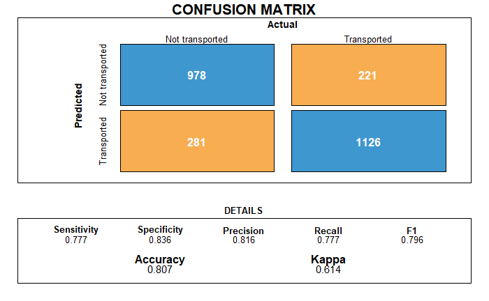

```r
# creating evaluation matrix
prediction <-predict(rf_2.0, test_data, "response")
prediction <- factor(prediction,levels=c(0,1))

cm <- confusionMatrix(prediction, as.factor(test_data$Transported))

draw_confusion_matrix(cm)
```

As expected for a more complex model, removing even marginal information lowers the accuracy, so there is no need to do so.

# Results and conclusion:

Those are our predictions with regards to the passengers whose status is currently unknown:

```r
# predicting transported label on the test set
test_pred_log_reg <-predict(model_cv, test_transported)
test_pred_rf <- predict(rf, test_transported)

 # creating a df with the predictions
columns_names <- c("PassengerId", "Transported")
logreg_predictions_df <- data.frame(test$PassengerId, test_pred_log_reg)
rf_predictions_df <- data.frame(test$PassengerId, test_pred_rf)

colnames(logreg_predictions_df) <- columns_names
colnames(rf_predictions_df) <- columns_names

logreg_predictions_df$Transported <- logreg_predictions_df$Transported == 1
rf_predictions_df$Transported <- rf_predictions_df$Transported == 1
```

here presented in graphic form

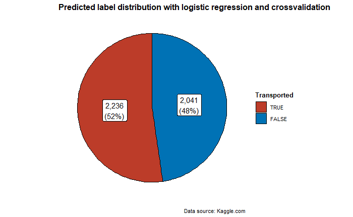

```r
# plotting transported predictions distributions
# and showing datasets for both models
ggpiestats( data = logreg_predictions_df,
             x = Transported,
             label = "both",
             title = "Predicted label distribution with logistic regression and crossvalidation",
             legend.title = "Transported",
             results.subtitle = FALSE,
             package = "ggsci",
             palette = "default_nejm",
             caption = "Data source: Kaggle.com",)
```

```r
print(logreg_predictions_df)
```

| PassengerId | Transported |
| --- | --- |
| 0047_03 | FALSE |
| 0262_01 | FALSE |
| 0308_01 | TRUE |
| 0344_02 | FALSE |
| 0366_01 | TRUE |
| 0419_02 | TRUE |
| 0493_01 | TRUE |
| 0625_02 | TRUE |
| 0676_01 | TRUE |
| 0887_02 | FALSE |

[output cut: 990 more lines]

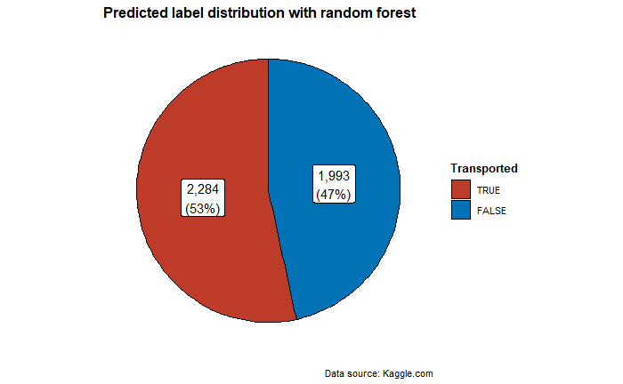

```r
ggpiestats( data = rf_predictions_df,
             x = Transported,
             label = "both",
             title = "Predicted label distribution with random forest",
             legend.title = "Transported",
             results.subtitle = FALSE,
             package = "ggsci",
             palette = "default_nejm",
             caption = "Data source: Kaggle.com")
```

```r
print(rf_predictions_df)
```

|  | PassengerId | Transported |
| --- | --- | --- |
| 1 | 0047_03 | FALSE |
| 2 | 0262_01 | FALSE |
| 3 | 0308_01 | TRUE |
| 4 | 0344_02 | FALSE |
| 5 | 0366_01 | TRUE |
| 6 | 0419_02 | TRUE |
| 7 | 0493_01 | TRUE |
| 8 | 0625_02 | TRUE |
| 9 | 0676_01 | FALSE |
| 10 | 0887_02 | FALSE |

[output cut: 990 more lines]

```r
NA
```

Summarizing we expect between 52% and 53% of the passengers whose status is unknown to have been transported to an alternative dimension, perhaps slightly higher than an initial analysis would have led us to believe.

We are quite confident the anomaly hit decks B and C, targeting disproportionately passengers from Europa going to Cancri 55 e, people in cryosleep and people who were bunked on the starboard side of the ship.

Families, who’s relatives on-board profile fits those categories, are strongly encouraged to contact their closest galactic policy center with the passenger’s information.

# References

- Spaceship Titanic | Kaggle (2022, June 13). https://www.kaggle.com/competitions/spaceship-titanic
- Azzimonti, D. (2022, June 13). Slides by professor Dario Azzimonti. iCorsi. https://www.icorsi.ch/course/view.php?id=13860
- Papandrea, M. (2022, June 13). Slides by professor Michela Papandrea. iCorsi. https://www.icorsi.ch/course/view.php?id=12716
- Durazo, L. (2022, June 13). How to use Kaggle API to download datasets in R. Medium. https://medium.com/mcd-unison/how-to-use-kaggle-api-to-download-datasets-in-r-312179c7a99c